# UN ANALISIS EXPLORATORIO EN EL MUNDO DE LA NBA

## Autor: Adrian Gonzalez Retamosa

## Asignatura: Machine Learning

## Fecha: 29/10/2020

### ESQUEMA

```
1. Presentacion del Data Set
2. Analisis de valores nulos y duplicados
3. Analisis de los salarios por equipo, pais de nacimiento y edad
4. Histogramas y graficos de dispersion entre las principales variables
5. Bibliografia
```

### 1. Presentacion del Data Set

##### 1.1. Diccionario del Data Set

Las variables a trabjar son:

```
Player - Nombre jugador

Salary - Salario del jugador

NBA_Country - Pais origen jugador NBA_DraftNumber - Numero en el Draft del jugador Age - años

Tm - Equipo del jugador

G - Partidos jugados

MPMP = Minutos jugados

PER - Índice de eficiencia del jugador Una medida de la producción por minuto estandarizada de manera que el promedio de la liga es 15.

TSp - Porcentaje de tiros reales Una medida de la eficiencia de los tiros que tiene en cuenta tiros de campo de 2 puntos, tiros de campo de 3 puntos y tiros libres.

3PAr - Tasa de intentos de 3 puntos Porcentaje de intentos de FG desde el rango de 3 puntos FTr - Tasa de intentos de tiros libres Número de intentos de FT por intento de tiro libre

ORBp - Porcentaje de rebote ofensivo Una estimación del porcentaje de rebotes ofensivos disponibles que un jugador agarró mientras estaba en la cancha.

DRBp - Porcentaje de rebote defensivo Una estimación del porcentaje de rebotes defensivos disponibles que un jugador agarró mientras estaba en la cancha.

TRBp - Porcentaje de rebote total Una estimación del porcentaje de rebotes disponibles que un jugador agarró mientras estaba en la cancha.

ASTp - Porcentaje de asistencia Una estimación del porcentaje de goles de campo de un compañero de equipo que un jugador ayudó mientras estaba en la cancha.

STLp - Porcentaje de robo Una estimación del porcentaje de posesiones del oponente que terminan con un robo del jugador mientras estaba en la cancha.

BLKp - Porcentaje de bloqueo Una estimación del porcentaje de intentos de gol de campo de dos puntos del oponente bloqueados por el jugador mientras estaba en el suelo.

TOVp - Porcentaje de rotación Una estimación de las pérdidas de balón cometidas por cada 100 jugadas.

USGp - Porcentaje de uso Una estimación del porcentaje de jugadas de equipo utilizadas por un jugador mientras estaba en la cancha.

OWS - Una estimación del número de victorias aportadas por un jugador debido a su infracción.

DWS - Una estimación del número de victorias aportadas por un jugador debido a su defensa.

WS - Una estimación del número de victorias aportadas por un jugador.

WS / 48 - Acciones de ganancias por 48 minutos Una estimación del número de victorias aportadas por un jugador por 48 minutos (el promedio de la liga es aproximadamente .100)

OBPM - Una estimación de la puntuación de la caja de los puntos ofensivos por cada 100 posesiones que un jugador contribuyó por encima de un jugador promedio de la liga, traducido a un equipo promedio.

DBPM - Una estimación de la puntuación de caja de los puntos defensivos por cada 100
posesiones que un jugador contribuyó por encima de un jugador promedio de la liga, traducido a un equipo promedio.

BPM - Una estimación de la puntuación de caja de los puntos por cada 100 posesiones que un jugador contribuyó por encima de un jugador promedio de la liga, traducido a un equipo promedio.

VORP - Valor sobre el jugador de reemplazo Una estimación de la puntuación de los puntos por cada 100 posesiones del EQUIPO que un jugador contribuyó por encima de un jugador de nivel de reemplazo (-2.0), traducido a un equipo promedio y prorrateado a una temporada de 82 juegos
```

##### 1.2. Carga de las librerias

```python
import numpy as np
import pandas as pd
import matplotlib.pyplot as plt
import seaborn as sns
```

##### 1.3. Carga del Data Set

```python
df_nba = pd.read_csv('../data/nba1.csv', sep=',')
```

##### 1.4. Cambiamos el nombre de ciertas columnas

```python
df_nba.columns = ['Player',
                  'Salary',
                  'NBA_Country',
                  'NBA_DraftNumber',
                  'Age',
                  'Tm',
                  'G',
                  'MP',
                  'PER',
                  'TSp',
                  '3PAr',
                  'FTr',
                  'ORBp',
                  'DRBp',
                  'TRBp',
                  'ASTp',
                  'STLp',
                  'BLKp',
                  'TOVp',
                  'USGp',
                  'OWS',
                  'DWS',
                  'WS',
                  'WS_48',
                  'OBPM',
                  'DBPM',
                  'BPM',
                  'VORP']
```

##### 1.5. Tamaño del Data Set

```python
df_nba.shape
```

```
(485, 28)
```

##### 1.6. Informacion del Data Set

```python
df_nba.info()
```

```
<class 'pandas.core.frame.DataFrame'>
RangeIndex: 485 entries, 0 to 484
Data columns (total 28 columns):
 #   Column           Non-Null Count  Dtype
---  ------           --------------  -----
 0   Player           485 non-null    object
 1   Salary           485 non-null    int64
 2   NBA_Country      485 non-null    object
 3   NBA_DraftNumber  485 non-null    int64
 4   Age              485 non-null    int64
 5   Tm               485 non-null    object
 6   G                485 non-null    int64
 7   MP               485 non-null    int64
 8   PER              485 non-null    float64
 9   TSp              483 non-null    float64
```

[output cut: 20 more lines]

##### 1.7. Informacion de cada columna

```python
for variable in list(df_nba.columns):
    print(variable + ' --> ' + str(df_nba[variable].nunique()) + ' , data type '  + str(df_nba[variable].dtype))
```

```
Player --> 483 , data type object
Salary --> 303 , data type int64
NBA_Country --> 44 , data type object
NBA_DraftNumber --> 60 , data type int64
Age --> 23 , data type int64
Tm --> 31 , data type object
G --> 77 , data type int64
MP --> 441 , data type int64
PER --> 205 , data type float64
TSp --> 222 , data type float64
3PAr --> 305 , data type float64
FTr --> 277 , data type float64
ORBp --> 133 , data type float64
DRBp --> 203 , data type float64
TRBp --> 167 , data type float64
ASTp --> 226 , data type float64
STLp --> 40 , data type float64
BLKp --> 65 , data type float64
TOVp --> 165 , data type float64
USGp --> 198 , data type float64
OWS --> 80 , data type float64
DWS --> 45 , data type float64
WS --> 99 , data type float64
WS_48 --> 236 , data type float64
OBPM --> 131 , data type float64
DBPM --> 108 , data type float64
BPM --> 156 , data type float64
VORP --> 59 , data type float64
```

##### 1.8. Calculamos los principales estadisticos para cada variable

```python
round(df_nba.describe(),3).T
```

|  | count | mean | std | min | 25% | 50% | 75% | max |
| --- | --- | --- | --- | --- | --- | --- | --- | --- |
| Salary | 485.0 | 6636507.499 | 7392601.908 | 46080.000 | 1471382.000 | 3202217.000 | 1.000000e+07 | 3.468255e+07 |
| NBA_DraftNumber | 485.0 | 29.452 | 21.126 | 1.000 | 11.000 | 25.000 | 4.700000e+01 | 6.200000e+01 |
| Age | 485.0 | 26.264 | 4.272 | 19.000 | 23.000 | 26.000 | 2.900000e+01 | 4.100000e+01 |
| G | 485.0 | 50.167 | 24.875 | 1.000 | 29.000 | 59.000 | 7.100000e+01 | 7.900000e+01 |
| MP | 485.0 | 1154.142 | 811.357 | 1.000 | 381.000 | 1134.000 | 1.819000e+03 | 2.898000e+03 |
| PER | 485.0 | 13.261 | 8.769 | -41.100 | 9.800 | 13.200 | 1.650000e+01 | 1.341000e+02 |
| TSp | 483.0 | 0.535 | 0.112 | 0.000 | 0.506 | 0.545 | 5.820000e-01 | 1.500000e+00 |
| 3PAr | 483.0 | 0.337 | 0.227 | 0.000 | 0.167 | 0.346 | 4.810000e-01 | 1.000000e+00 |
| FTr | 483.0 | 0.263 | 0.295 | 0.000 | 0.155 | 0.231 | 3.200000e-01 | 5.333000e+00 |
| ORBp | 485.0 | 4.874 | 4.583 | 0.000 | 1.800 | 3.200 | 7.000000e+00 | 3.590000e+01 |
| DRBp | 485.0 | 14.951 | 6.848 | 0.000 | 10.200 | 14.000 | 1.880000e+01 | 3.760000e+01 |
| TRBp | 485.0 | 9.908 | 4.956 | 0.000 | 6.200 | 8.700 | 1.330000e+01 | 2.650000e+01 |
| ASTp | 485.0 | 12.948 | 9.112 | 0.000 | 6.900 | 9.900 | 1.760000e+01 | 4.940000e+01 |
| STLp | 485.0 | 1.529 | 0.990 | 0.000 | 1.000 | 1.500 | 1.900000e+00 | 1.250000e+01 |
| BLKp | 485.0 | 1.713 | 1.684 | 0.000 | 0.600 | 1.200 | 2.200000e+00 | 1.340000e+01 |
| TOVp | 483.0 | 13.140 | 6.115 | 0.000 | 9.900 | 12.500 | 1.575000e+01 | 6.670000e+01 |
| USGp | 485.0 | 18.897 | 5.941 | 0.000 | 15.000 | 17.900 | 2.220000e+01 | 4.510000e+01 |
| OWS | 485.0 | 1.275 | 1.881 | -2.300 | 0.000 | 0.800 | 2.000000e+00 | 1.140000e+01 |
| DWS | 485.0 | 1.176 | 1.035 | 0.000 | 0.300 | 1.000 | 1.800000e+00 | 5.600000e+00 |
| WS | 485.0 | 2.455 | 2.674 | -1.200 | 0.300 | 1.800 | 3.600000e+00 | 1.500000e+01 |
| WS_48 | 485.0 | 0.080 | 0.163 | -1.063 | 0.040 | 0.083 | 1.230000e-01 | 2.713000e+00 |
| OBPM | 485.0 | -1.271 | 5.026 | -36.500 | -2.700 | -1.100 | 4.000000e-01 | 6.870000e+01 |
| DBPM | 485.0 | -0.489 | 2.389 | -14.300 | -1.700 | -0.400 | 1.000000e+00 | 6.800000e+00 |
| BPM | 485.0 | -1.760 | 5.661 | -49.200 | -3.600 | -1.300 | 5.000000e-01 | 5.440000e+01 |
| VORP | 485.0 | 0.599 | 1.246 | -1.300 | -0.100 | 0.100 | 9.000000e-01 | 8.600000e+00 |

##### 1.9. Comprobamos el nombre de todos los jugadores del Data Set

```python
for Player in df_nba.Player.unique():
    print(Player) #nombre de todos los jugadores
```

```
Zhou Qi
Zaza Pachulia
Zach Randolph
Zach LaVine
Zach Collins
Yogi Ferrell
Xavier Silas
Xavier Rathan-Mayes
Wilson Chandler
Willy Hernangomez
Willie Reed
Willie Cauley-Stein
Will Barton
Wesley Matthews
Wesley Johnson
Wesley Iwundu
Wayne Selden
Wayne Ellington
Wade Baldwin
Vince Hunter
Vince Carter
Victor Oladipo
Vander Blue
Udonis Haslem
Tyus Jones
Tyson Chandler
Tyreke Evans
Tyler Zeller
Tyler Ulis
Tyler Lydon
Tyler Johnson
Tyler Ennis
Tyler Dorsey
Tyler Cavanaugh
Troy Williams
Troy Daniels
Tristan Thompson
Trey McKinney-Jones
Trey Lyles
Trey Burke
```

[output cut: 428 more lines]

```
Amir Johnson
Allen Crabbe
Alfonzo McKinnie
Al-Farouq Aminu
Alex Poythress
Alex Len
Alex Abrines
Alec Burks
Alan Williams
Al Jefferson
Al Horford
Abdel Nader
Aaron Harrison
Aaron Gordon
Aaron Brooks
```

### 2. Analisis de valores nulos y duplicados

##### 2.1. Eliminamos valores repetidos si los hubiese

```python
df_nba = df_nba.drop_duplicates()
df_nba.shape #vemos que no hay registros duplicados
```

```
(485, 28)
```

##### 2.2. Comprobamos los valores nulos que hay en cada columna y eliminamos los existentes

```python
nba_nan_typ = pd.merge(df_nba.isnull().sum(axis = 0).sort_values().to_frame('NaN_values').reset_index(),
                     df_nba.dtypes.to_frame('types').reset_index(),
                     on = 'index',
                     how = 'inner')
nba_nan_typ
```

|  | index | NaN_values | types |
| --- | --- | --- | --- |
| 0 | Player | 0 | object |
| 1 | DBPM | 0 | float64 |
| 2 | OBPM | 0 | float64 |
| 3 | WS_48 | 0 | float64 |
| 4 | WS | 0 | float64 |
| 5 | DWS | 0 | float64 |
| 6 | OWS | 0 | float64 |
| 7 | USGp | 0 | float64 |
| 8 | BLKp | 0 | float64 |
| 9 | STLp | 0 | float64 |
| 10 | ASTp | 0 | float64 |
| 11 | TRBp | 0 | float64 |
| 12 | BPM | 0 | float64 |
| 13 | DRBp | 0 | float64 |
| 14 | PER | 0 | float64 |
| 15 | MP | 0 | int64 |
| 16 | G | 0 | int64 |
| 17 | Tm | 0 | object |
| 18 | Age | 0 | int64 |
| 19 | NBA_DraftNumber | 0 | int64 |
| 20 | NBA_Country | 0 | object |
| 21 | Salary | 0 | int64 |
| 22 | ORBp | 0 | float64 |
| 23 | VORP | 0 | float64 |
| 24 | FTr | 2 | float64 |
| 25 | 3PAr | 2 | float64 |
| 26 | TSp | 2 | float64 |
| 27 | TOVp | 2 | float64 |

```python
#eliminamos esos valores NaN
df_nba = df_nba.dropna()
```

### 3. Analisis de los salarios por equipo, pais de nacimiento y edad

##### 3.1. Vemos que jugadores han sido elegidos en el top 3 del Draft

```python
#jugadores elegido en el top 3 del Draft
df_nba.iloc[:,[0,3]][df_nba.NBA_DraftNumber <= 3].sort_values('NBA_DraftNumber')
```

|  | Player | NBA_DraftNumber |
| --- | --- | --- |
| 228 | Karl-Anthony Towns | 1 |
| 257 | John Wall | 1 |
| 377 | Derrick Rose | 1 |
| 466 | Andrew Bogut | 1 |
| 201 | Kyrie Irving | 1 |
| 193 | LeBron James | 1 |
| 453 | Ben Simmons | 1 |
| 451 | Blake Griffin | 1 |
| 359 | Dwight Howard | 1 |
| 462 | Anthony Davis | 1 |
| 464 | Andrew Wiggins | 1 |
| 170 | Markelle Fultz | 1 |
| 344 | Evan Turner | 2 |
| 353 | Emeka Okafor | 2 |
| 443 | Brandon Ingram | 2 |
| 375 | Derrick Williams | 2 |
| 306 | Jabari Parker | 2 |
| 21 | Victor Oladipo | 2 |
| 217 | Kevin Durant | 2 |
| 200 | LaMarcus Aldridge | 2 |
| 192 | Lonzo Ball | 2 |
| 163 | Marvin Williams | 2 |
| 156 | Michael Beasley | 2 |
| 154 | Michael Kidd-Gilchrist | 2 |
| 25 | Tyson Chandler | 2 |
| 407 | D'Angelo Russell | 2 |
| 429 | Carmelo Anthony | 3 |
| 445 | Bradley Beal | 3 |
| 295 | James Harden | 3 |
| 351 | Enes Kanter | 3 |
| 303 | Jahlil Okafor | 3 |
| 281 | Jaylen Brown | 3 |
| 279 | Jayson Tatum | 3 |
| 261 | Joel Embiid | 3 |
| 123 | Otto Porter | 3 |
| 115 | Pau Gasol | 3 |
| 379 | Derrick Favors | 3 |
| 480 | Al Horford | 3 |

##### 3.2. Vemos la edad media y el salario medio por equipo

```python
mean_tm = df_nba.iloc[:,[4,1,5]].groupby('Tm').mean().sort_values('Tm').T
round(mean_tm, 3)
```

| Tm | ATL | BOS | BRK | CHI | CHO | CLE | DAL | DEN | DET | GSW | ... | ORL | PHI | PHO | POR | SAC | SAS | TOR | TOT | UTA | WAS |
| --- | --- | --- | --- | --- | --- | --- | --- | --- | --- | --- | --- | --- | --- | --- | --- | --- | --- | --- | --- | --- | --- |
| Age | 24.812 | 25.133 | 25.083 | 24.286 | 25.786 | 29.3 | 26.889 | 26.154 | 25.357 | 28.188 | ... | 25.667 | 24.750 | 24.214 | 24.571 | 26.250 | 28.600 | 25.308 | 26.836 | 25.824 | 27.231 |
| Salary | 4296620.500 | 7327208.933 | 6488600.083 | 3766411.857 | 8379765.643 | 11215880.2 | 4398073.667 | 7487877.769 | 5729819.714 | 8540607.438 | ... | 6431496.133 | 5561474.438 | 4072399.714 | 8248284.214 | 5443671.833 | 7549140.267 | 8759858.154 | 5216966.073 | 5728685.235 | 9449678.154 |

2 rows × 31 columns

##### 3.3. Calculamos el salario total que paga cada equipo

```python
sum_tm = df_nba.iloc[:,[1,5]].groupby('Tm').sum().sort_values('Tm').T
round(sum_tm, 3)
```

| Tm | ATL | BOS | BRK | CHI | CHO | CLE | DAL | DEN | DET | GSW | ... | ORL | PHI | PHO | POR | SAC | SAS | TOR | TOT | UTA | WAS |
| --- | --- | --- | --- | --- | --- | --- | --- | --- | --- | --- | --- | --- | --- | --- | --- | --- | --- | --- | --- | --- | --- |
| Salary | 68745928 | 109908134 | 77863201 | 52729766 | 117316719 | 112158802 | 79165326 | 97342411 | 80217476 | 136649719 | ... | 96472442 | 88983591 | 57013596 | 115475979 | 65324062 | 113237104 | 113878156 | 286933134 | 97387649 | 122845816 |

1 rows × 31 columns

##### 3.4. Vamos a crear una variable dummy que valga 1 si el jugador es de USA y 0 en el resto de caso

```python
def usa_f(x): #funcion
    if x == 'USA': #si es USA vale 1 y si no 0
        return 1
    else:
        return 0

df_nba['USA']=df_nba.NBA_Country.map(usa_f) # creo una columna que me haga esa funcion para toda la columna NBA_Country
df_nba
```

|  | Player | Salary | NBA_Country | NBA_DraftNumber | Age | Tm | G | MP | PER | TSp | ... | USGp | OWS | DWS | WS | WS_48 | OBPM | DBPM | BPM | VORP | USA |
| --- | --- | --- | --- | --- | --- | --- | --- | --- | --- | --- | --- | --- | --- | --- | --- | --- | --- | --- | --- | --- | --- |
| 0 | Zhou Qi | 815615 | China | 43 | 22 | HOU | 16 | 87 | 0.6 | 0.303 | ... | 19.5 | -0.4 | 0.1 | -0.2 | -0.121 | -10.6 | 0.5 | -10.1 | -0.2 | 0 |
| 1 | Zaza Pachulia | 3477600 | Georgia | 42 | 33 | GSW | 66 | 937 | 16.8 | 0.608 | ... | 17.2 | 1.7 | 1.4 | 3.1 | 0.160 | -0.6 | 1.3 | 0.8 | 0.7 | 0 |
| 2 | Zach Randolph | 12307692 | USA | 19 | 36 | SAC | 59 | 1508 | 17.3 | 0.529 | ... | 27.6 | 0.3 | 1.1 | 1.4 | 0.046 | -0.6 | -1.3 | -1.9 | 0.0 | 1 |
| 3 | Zach LaVine | 3202217 | USA | 13 | 22 | CHI | 24 | 656 | 14.6 | 0.499 | ... | 29.5 | -0.1 | 0.5 | 0.4 | 0.027 | -0.7 | -2.0 | -2.6 | -0.1 | 1 |
| 4 | Zach Collins | 3057240 | USA | 10 | 20 | POR | 62 | 979 | 8.2 | 0.487 | ... | 15.5 | -0.4 | 1.2 | 0.8 | 0.038 | -3.7 | 0.9 | -2.9 | -0.2 | 1 |
| ... | ... | ... | ... | ... | ... | ... | ... | ... | ... | ... | ... | ... | ... | ... | ... | ... | ... | ... | ... | ... | ... |
| 480 | Al Horford | 27734405 | Dominican Rep... | 3 | 31 | BOS | 70 | 2219 | 17.5 | 0.577 | ... | 18.4 | 3.8 | 3.8 | 7.6 | 0.164 | 1.1 | 3.0 | 4.1 | 3.4 | 0 |
| 481 | Abdel Nader | 1167333 | Egypt | 58 | 24 | BOS | 44 | 463 | 5.7 | 0.464 | ... | 16.9 | -0.6 | 0.7 | 0.0 | 0.004 | -5.3 | 0.3 | -5.0 | -0.3 | 0 |
| 482 | Aaron Harrison | 83129 | USA | 62 | 23 | DAL | 7 | 164 | 6.6 | 0.411 | ... | 14.4 | -0.1 | 0.2 | 0.1 | 0.019 | -3.2 | 0.3 | -2.9 | 0.0 | 1 |
| 483 | Aaron Gordon | 5504420 | USA | 4 | 22 | ORL | 55 | 1838 | 16.6 | 0.531 | ... | 24.5 | 1.1 | 1.9 | 3.0 | 0.078 | 0.1 | -0.1 | 0.1 | 1.0 | 1 |
| 484 | Aaron Brooks | 2116955 | USA | 26 | 33 | MIN | 31 | 188 | 10.1 | 0.508 | ... | 19.7 | 0.1 | 0.1 | 0.2 | 0.039 | -0.5 | -3.7 | -4.1 | -0.1 | 1 |

483 rows × 29 columns

3.4.1 Vamos a contar cuantos jugadores son de USA y cuantos del extranjero

```python
df_nba.iloc[:, [0,-1]].groupby(['USA']).count()
```

| USA | Player |
| --- | --- |
| 0 | 111 |
| 1 | 372 |

3.4.2 Calculamos la media salarial para los jugadores de USA

```python
print(df_nba[df_nba.USA == 1].Salary.mean())
```

```
6545490.338709678
```

3.4.3 Calculamos la media salarial para los jugadores que no son de USA

```python
print(df_nba[df_nba.USA == 0].Salary.mean())
```

```
7046470.369369369
```

Observamos que en media los jugadores que no son de USA tienen un mayor salario, aunque esto se puede ver determinado por el hecho de que hay el triple de jugadores de USA

3.4.4 Calculamos el salario maximo para un jugador de USA

```python
print(df_nba[df_nba.USA == 1].Salary.max())
```

```
34682550
```

3.4.5 Calculamos el salario maximo para un jugador que no es de USA

```python
print(df_nba[df_nba.USA == 0].Salary.max())
```

```
27734405
```

Sin embargo, el mayor salario lo tiene un jugador de USA

```python
def rango_age(x):
    if x < 25:
        return 1
    elif 25 < x < 31:
        return 2
    elif 30 < x < 35:
        return 3
    elif x > 35:
        return 4

df_nba['rango_edad']=df_nba.Age.map(rango_age)
df_nba
```

|  | Player | Salary | NBA_Country | NBA_DraftNumber | Age | Tm | G | MP | PER | TSp | ... | OWS | DWS | WS | WS_48 | OBPM | DBPM | BPM | VORP | USA | rango_edad |
| --- | --- | --- | --- | --- | --- | --- | --- | --- | --- | --- | --- | --- | --- | --- | --- | --- | --- | --- | --- | --- | --- |
| 0 | Zhou Qi | 815615 | China | 43 | 22 | HOU | 16 | 87 | 0.6 | 0.303 | ... | -0.4 | 0.1 | -0.2 | -0.121 | -10.6 | 0.5 | -10.1 | -0.2 | 0 | 1.0 |
| 1 | Zaza Pachulia | 3477600 | Georgia | 42 | 33 | GSW | 66 | 937 | 16.8 | 0.608 | ... | 1.7 | 1.4 | 3.1 | 0.160 | -0.6 | 1.3 | 0.8 | 0.7 | 0 | 3.0 |
| 2 | Zach Randolph | 12307692 | USA | 19 | 36 | SAC | 59 | 1508 | 17.3 | 0.529 | ... | 0.3 | 1.1 | 1.4 | 0.046 | -0.6 | -1.3 | -1.9 | 0.0 | 1 | 4.0 |
| 3 | Zach LaVine | 3202217 | USA | 13 | 22 | CHI | 24 | 656 | 14.6 | 0.499 | ... | -0.1 | 0.5 | 0.4 | 0.027 | -0.7 | -2.0 | -2.6 | -0.1 | 1 | 1.0 |
| 4 | Zach Collins | 3057240 | USA | 10 | 20 | POR | 62 | 979 | 8.2 | 0.487 | ... | -0.4 | 1.2 | 0.8 | 0.038 | -3.7 | 0.9 | -2.9 | -0.2 | 1 | 1.0 |
| ... | ... | ... | ... | ... | ... | ... | ... | ... | ... | ... | ... | ... | ... | ... | ... | ... | ... | ... | ... | ... | ... |
| 480 | Al Horford | 27734405 | Dominican Rep... | 3 | 31 | BOS | 70 | 2219 | 17.5 | 0.577 | ... | 3.8 | 3.8 | 7.6 | 0.164 | 1.1 | 3.0 | 4.1 | 3.4 | 0 | 3.0 |
| 481 | Abdel Nader | 1167333 | Egypt | 58 | 24 | BOS | 44 | 463 | 5.7 | 0.464 | ... | -0.6 | 0.7 | 0.0 | 0.004 | -5.3 | 0.3 | -5.0 | -0.3 | 0 | 1.0 |
| 482 | Aaron Harrison | 83129 | USA | 62 | 23 | DAL | 7 | 164 | 6.6 | 0.411 | ... | -0.1 | 0.2 | 0.1 | 0.019 | -3.2 | 0.3 | -2.9 | 0.0 | 1 | 1.0 |
| 483 | Aaron Gordon | 5504420 | USA | 4 | 22 | ORL | 55 | 1838 | 16.6 | 0.531 | ... | 1.1 | 1.9 | 3.0 | 0.078 | 0.1 | -0.1 | 0.1 | 1.0 | 1 | 1.0 |
| 484 | Aaron Brooks | 2116955 | USA | 26 | 33 | MIN | 31 | 188 | 10.1 | 0.508 | ... | 0.1 | 0.1 | 0.2 | 0.039 | -0.5 | -3.7 | -4.1 | -0.1 | 1 | 3.0 |

483 rows × 30 columns

3.5.1 Vemos cuantos jugadores hay de cada rango

```python
df_nba.iloc[:, [0,-1]].groupby(['rango_edad']).count()
```

| rango_edad | Player |
| --- | --- |
| 1.0 | 191 |
| 2.0 | 166 |
| 3.0 | 59 |
| 4.0 | 17 |

3.5.2 Media salarial de los jugadores de 19-24 años

```python
print(df_nba[df_nba.rango_edad == 1].Salary.mean())
```

```
3088094.1937172776
```

```python
print(df_nba[df_nba.rango_edad == 2].Salary.mean())
```

```
9113447.222891565
```

```python
print(df_nba[df_nba.rango_edad == 3].Salary.mean())
```

```
11108278.423728814
```

3.5.5 Media salarial de los jugadores de 36-41 años

```python
print(df_nba[df_nba.rango_edad == 4].Salary.mean())
```

```
6187213.176470588
```

##### 3.6. Acontinuacion vamos a observar cuales son los jugadores que tienen los valores maximos en ciertas variables

3.6.1 Jugador con mayor salario

```python
print(df_nba.iloc[:,[0,1]][df_nba.Salary == df_nba.Salary.max()])
```

```
           Player    Salary
69  Stephen Curry  34682550
```

3.6.2 Jugador con mas partidos

```python
print(df_nba.iloc[:,[0,6]][df_nba.G == df_nba.G.max()])
```

```
                    Player   G
5             Yogi Ferrell  79
61   Taurean Waller-Prince  79
104         Raymond Felton  79
116            Patty Mills  79
117      Patrick Patterson  79
363          Dragan Bender  79
364         Doug McDermott  79
```

3.6.3 Jugador mas eficiente

```python
print(df_nba.iloc[:,[0,8]][df_nba.PER == df_nba.PER.max()])
```

```
              Player    PER
142  Naz Mitrou-Long  134.1
```

3.6.4 Jugador que mas victorias a porta a su equipo

```python
print(df_nba.iloc[:,[0,-8]][df_nba.WS == df_nba.WS.max()])
```

```
           Player    WS
295  James Harden  15.0
```

### 4. Histogramas y graficos de dispersion entre las principales variables

##### 4.1. Mapa de calor que muestra la correlacion entre todas las variables no categoricas

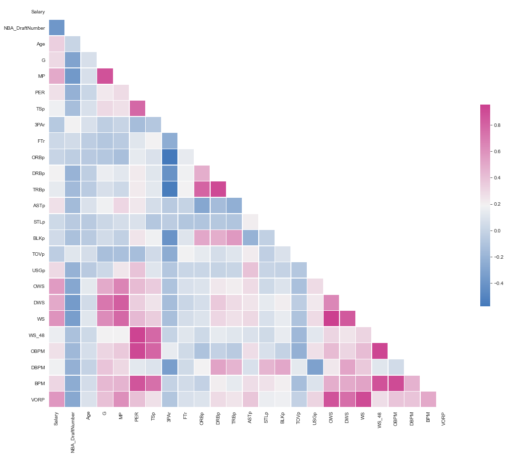

```python
df_nba1 = df_nba.drop(['Player', 'NBA_Country', 'Tm', 'USA', 'rango_edad'], axis = 'columns')
df_nba1.head() #eliminamos las variables categoricas

corr = df_nba1.corr()

mask = np.zeros_like(corr, dtype=np.bool) #para quitar la parte superior de la matriz
mask[np.triu_indices_from(mask)] = True

sns.set_style(style = 'white') #para que no se vean los cuadrados que sobran


f, ax = plt.subplots(figsize=(20, 15)) #dibujamos el lienzo

cmap = sns.diverging_palette(250, 700, as_cmap=True) #gama de colores que elegimos

sns.heatmap(corr, mask=mask, cmap=cmap,
        square=True,
        linewidths=.5, cbar_kws={"shrink": .5}, ax=ax) ;  #es un grafico de mapa de calor
```

##### 4.2. Histogramas de las variables

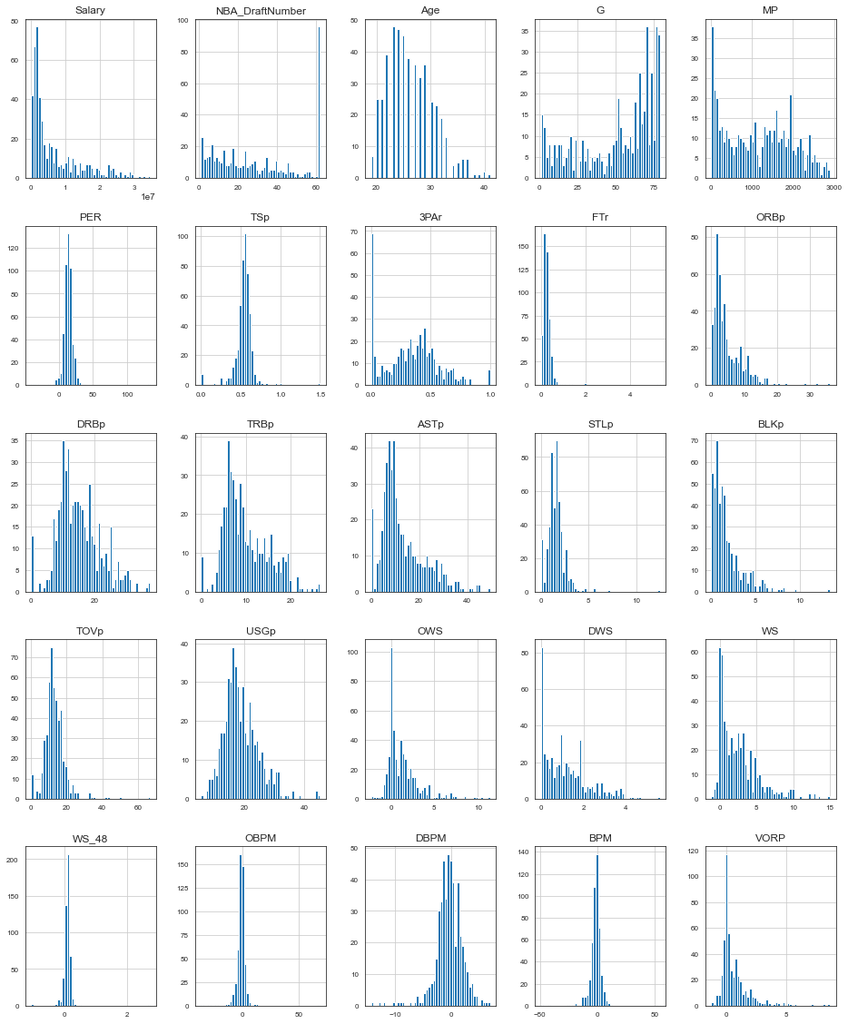

```python
df_nba1.hist(figsize=(16, 20), bins=50, xlabelsize=8, ylabelsize=8);
```

##### 4.3. Graficos de dispersion entre las variables mas relavantes

Vamos a construir un data frame con estas variables con el fin de ver relaciones entre el salario de los jugadores y ellas. Pero como podemos observar de haber algun tipo de relacion no es lineal.

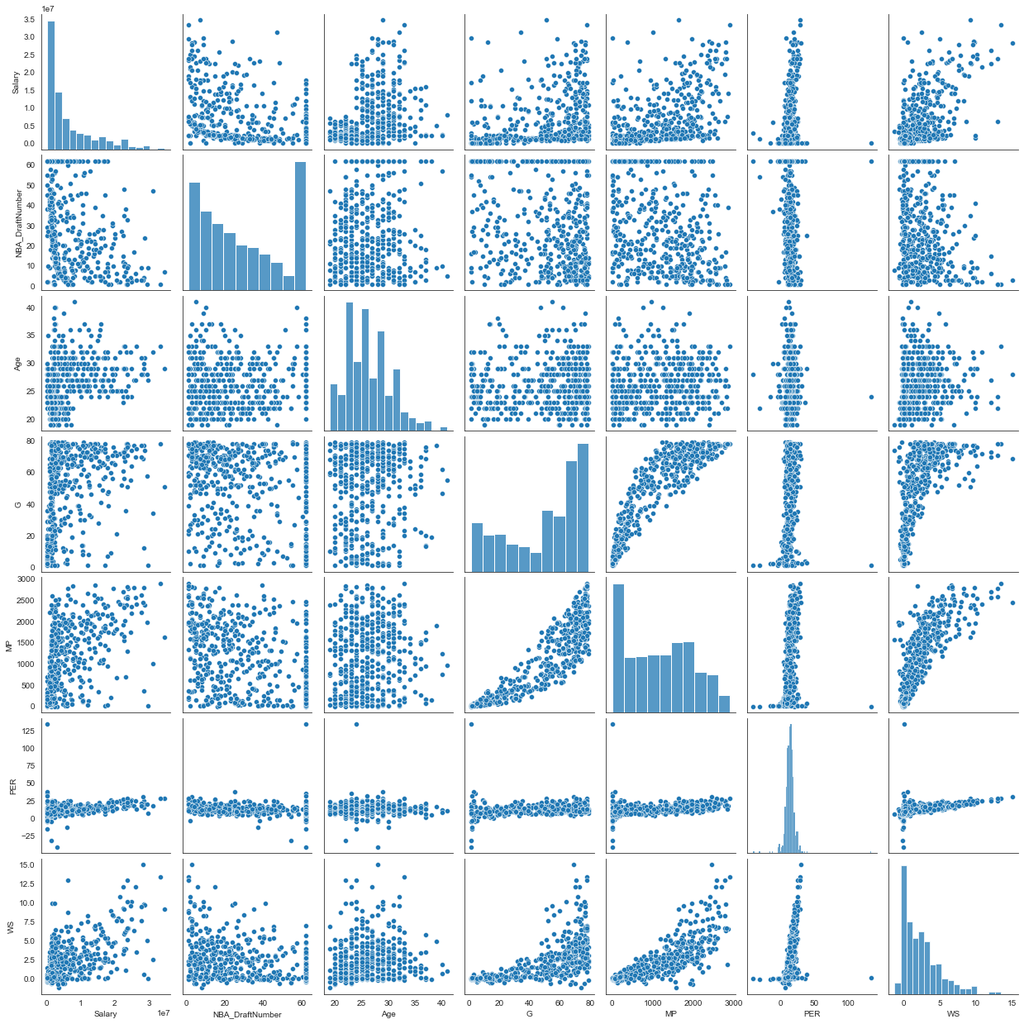

```python
df_nba2 = df_nba1.iloc[:,[0,1,2,3,4,5,19]]
sns.pairplot(df_nba2);
```

### 5. Bibliografia

1. https://www.kaggle.com/ekami66/detailed-exploratory-data-analysis-with-python
2. https://towardsdatascience.com/histograms-and-density-plots-in-python-f6bda88f5ac0
3. https://seaborn.pydata.org/tutorial/distributions.html
4. https://github.com/kessiezhang/NBA_Players_Salaries_Prediction/blob/master/02%20-%20Exploratory%20Data%20Analysis.ipynb
5. https://seaborn.pydata.org/generated/seaborn.pairplot.html
6. https://www.kaggle.com/dhimananubhav/workflow-for-visualizing-and-analyzing-stocks